# Загрузка библиотек

```python
import pandas as pd
import numpy as np
from lets_plot import *
from tqdm import tqdm
import seaborn as sns
import matplotlib.pyplot as plt
LetsPlot.setup_html()
```

## Загрузка данных

### Задание 1 (0.5 балла)

Для начала работы нам необходимо научиться читать набор данных. В данном домашнем задании мы поработаем с двумя наборами данных.

**covid.csv** ([источник](https://www.kaggle.com/gpreda/covid-world-vaccination-progress)) - статистика по вакцинированию от COVID19 по разным странам. Для данного датасета нет конкретной предсказательной переменной.

**hr.csv** ([источник](https://www.kaggle.com/arashnic/hr-analytics-job-change-of-data-scientists)) - набор данных большего размера. Он содержит статистику по людям, проходящим курсы по Big Data & ML. *Target* - 1 или 0, сменил ли человек работу после прохождения курсов - или нет.

Реализуйте методы `read_covid_dataset` и `read_hr_dataset`. Каждый из них принимает на вход путь к набору данных и возвращает выборку `X` и соответствующие метки `y`. В случае *covid* датасета `y` возвращается как `None`.

```python
def read_covid_dataset(path_to_csv):
    '''
    Возвращает пару из X и y. X - массив векторов. y - соответствующие векторам метки
    '''
    df = pd.read_csv(path_to_csv)
    X = df.copy()
    df['target'] = None
    y = df['target']
    return X, y


def read_hr_dataset(path_to_csv):
    '''
    Возвращает пару из X и y. X - массив векторов. y - соответствующие векторам метки
    '''
    df = pd.read_csv(path_to_csv)
    y = df['target'].copy()
    df = df.drop(['target'], axis = 1)
    X = df
    return X, y
```

```python
COVID_DATA_PATH = 'covid.csv'
HR_DATA_PATH = 'hr.csv'
```

```python
X_covid, _ = read_covid_dataset(COVID_DATA_PATH)
X_hr, y_hr = read_hr_dataset(HR_DATA_PATH)
```

## EDA

### Задание 2 (3.5 балла)

Выполните задание для датасетa *hr*.

Для дальнейшей работы с данными нужно обработать пропущенные значения в датасете. Существуют различные стратегии обработки пропущенных данных.

#### 1. (0.5 балла)

Для числовых признаков постройте распределения признаков. Для категориальных признаков выведите статистику по количеству значений признака.

```python
# print(X_hr.info())
# Строит гистограмму для каждого признака и сохраняет ее в plots
plots = []
for col in X_hr.columns:
    plots += [ggplot(X_hr, aes(col)) + geom_histogram() + ggtitle(col) + ggsize(1700, 850)]
```

```python
# Сохранение графиков в html-файлы
!mkdir lets-plot-images/hists
for i in tqdm(range(len(plots))):
    ggsave(plots[i], 'hists/' + str(X_hr.columns[i]) + '.html')
```

```
100%|██████████████████████████████████████████████████████████████████████████████████████████████████████████████████████████████████████████████████████████████████████████████| 13/13 [00:09<00:00,  1.39it/s]
```

Ввиду того, что графики lets_plot получаются "анимированными", пришлось их сохранить в отдельные файлы со ссылками, ибо с ними страница начинает подтормаживать.

Графики:

- enrollee_id
- city
- city_development_index
- gender
- relevent_experience
- enrolled_university
- education_level
- major_discipline
- experience
- company_size
- company_type
- last_new_job
- training_hours

#### 2. (0.5 балла)

Удалите все строки, где есть хотя бы одно пропущенное значение признака. Насколько сильно уменьшился размер датасета? Как изменились распределения признаков/статистика по количеству значений признаков?

```python
print(f'Исходный размер датасета hr = {len(X_hr)}')
```

```
Исходный размер датасета hr = 19158
```

```python
X_hr_dropna = X_hr.dropna()# YOUR_CODE
```

```python
print(f'Pазмер датасета hr без NaN = {len(X_hr_dropna)}')
```

```
Pазмер датасета hr без NaN = 8955
```

```python
# Построение гистограмм изначального датасета и датасета с выброшенными NA
plots_comp = []
for i in tqdm(range(len(X_hr.columns))):
    X_hr_comparsion1 = pd.DataFrame()
    X_hr_comparsion1[X_hr.columns[i]] = X_hr[X_hr.columns[i]]#.copy()
    X_hr_comparsion1['label'] = 'with NA'
    X_hr_comparsion2 = pd.DataFrame()
    X_hr_comparsion2[X_hr.columns[i]] = X_hr_dropna[X_hr.columns[i]]#.copy()
    X_hr_comparsion2['label'] = 'without NA'
    X_hr_comparsion = pd.concat([X_hr_comparsion1, X_hr_comparsion2], axis=0)
    plots_comp += [ggplot(X_hr_comparsion, aes(x= X_hr.columns[i])) + geom_histogram(col = 'darkblue', fill='lightblue') +\
    facet_wrap('label') + ggtitle(X_hr.columns[i] + '_comparsion') + ggsize(1700,850)]
```

```
100%|█████████████████████████████████████████████████████████████████████████████████████████████████████████████████████████████████████████████████████████████████████████████| 13/13 [00:00<00:00, 231.75it/s]
```

```python
# Сохранение графиков в html-файлы
!mkdir lets-plot-images/dropna_comp
for i in tqdm(range(len(plots_comp))):
    ggsave(plots_comp[i], "dropna_comp/" + str(X_hr.columns[i]) + '.comparsion.html')
```

```
100%|██████████████████████████████████████████████████████████████████████████████████████████████████████████████████████████████████████████████████████████████████████████████| 13/13 [00:04<00:00,  2.76it/s]
```

Графики:

- enrollee_id_comparsion
- city_comparsion
- city_development_index_comparsion
- gender_comparsion
- relevent_experience_comparsion
- enrolled_university_comparsion
- education_level_comparsion
- major_discipline_comparsion
- experience_comparsion
- company_size_comparsion
- company_type_comparsion
- last_new_job_comparsion
- training_hours_comparsion

Размер датасета сократился $\frac{19158}{8955} \approx 2.14$ раза.

Почти все распределения уменьшились в той же степени, несильно потеряв форму первоначального распределения, кроме **education_level** и **expierence**

Давайте попробуем избежать сокращения размера датасета.

#### 3. (1 балл)

Для числовых признаков заполните пропущенные данные средним/медианой/модой данного признака. Объясните свой выбор. (Часть строк с NaN значениями можно удалить, если размер датасета уменьшится <15%)

#### 4. (1 балл)

Для категориальных признаков заполните пропущенные значения самой встречающейся категорией или создайте отдельную категорию пропущенных значений. Объясните свой выбор. (Часть строк с NaN значениями можно удалить, если размер датасета уменьшится <15%)

NaN будем заполнять по таблице:

| Тип признака с NaN | Замена |
| --- | --- |
| Количественный | Среднее |
| Категориальный | Мода |

Чтобы вносить как можно меньше шумов в данные

```python
# Посмотрим на типы данных в датасете, а также наличие NaN в них, и определим, какие столбцы чем заполнять
X_hr
```

|  | enrollee_id | city | city_development_index | gender | relevent_experience | enrolled_university | education_level | major_discipline | experience | company_size | company_type | last_new_job | training_hours |
| --- | --- | --- | --- | --- | --- | --- | --- | --- | --- | --- | --- | --- | --- |
| 0 | 8949 | city_103 | 0.920 | Male | Has relevent experience | no_enrollment | Graduate | STEM | >20 | NaN | NaN | 1 | 36 |
| 1 | 29725 | city_40 | 0.776 | Male | No relevent experience | no_enrollment | Graduate | STEM | 15 | 50-99 | Pvt Ltd | >4 | 47 |
| 2 | 11561 | city_21 | 0.624 | NaN | No relevent experience | Full time course | Graduate | STEM | 5 | NaN | NaN | never | 83 |
| 3 | 33241 | city_115 | 0.789 | NaN | No relevent experience | NaN | Graduate | Business Degree | <1 | NaN | Pvt Ltd | never | 52 |
| 4 | 666 | city_162 | 0.767 | Male | Has relevent experience | no_enrollment | Masters | STEM | >20 | 50-99 | Funded Startup | 4 | 8 |
| ... | ... | ... | ... | ... | ... | ... | ... | ... | ... | ... | ... | ... | ... |
| 19153 | 7386 | city_173 | 0.878 | Male | No relevent experience | no_enrollment | Graduate | Humanities | 14 | NaN | NaN | 1 | 42 |
| 19154 | 31398 | city_103 | 0.920 | Male | Has relevent experience | no_enrollment | Graduate | STEM | 14 | NaN | NaN | 4 | 52 |
| 19155 | 24576 | city_103 | 0.920 | Male | Has relevent experience | no_enrollment | Graduate | STEM | >20 | 50-99 | Pvt Ltd | 4 | 44 |
| 19156 | 5756 | city_65 | 0.802 | Male | Has relevent experience | no_enrollment | High School | NaN | <1 | 500-999 | Pvt Ltd | 2 | 97 |
| 19157 | 23834 | city_67 | 0.855 | NaN | No relevent experience | no_enrollment | Primary School | NaN | 2 | NaN | NaN | 1 | 127 |

19158 rows × 13 columns

```python
# Найдем столбцы с NaN-ами
cols_with_na = []
for col in X_hr.columns:
    if X_hr[col].isnull().values.any():
        print(f'Замены требуются в столбце {col}')
        cols_with_na += [col]
#     print(f'В столбце {col} NaN {"присутствуют" if X_hr[col].isnull().values.any() else "отсутствуют"}')
```

```
Замены требуются в столбце gender
Замены требуются в столбце enrolled_university
Замены требуются в столбце education_level
Замены требуются в столбце major_discipline
Замены требуются в столбце experience
Замены требуются в столбце company_size
Замены требуются в столбце company_type
Замены требуются в столбце last_new_job
```

Таким образом, все признаки относятся к категориальным, будем заполнять пропуски модой.

```python
test = X_hr.copy()
m = test['gender'].mode()
test['gender'] = test['gender'].fillna(m[0])#test['gender'].dropna().mode())
test['gender']
# test['gender'].mode()
```

```
0        Male
1        Male
2        Male
3        Male
4        Male
         ...
19153    Male
19154    Male
19155    Male
19156    Male
19157    Male
Name: gender, Length: 19158, dtype: object
```

Так же, отметим, что признак **target** в y - категориальный признак

```python
def fill_na(X, y):
    # Возвращает данные без NaN значений
    X_dropna = X.dropna().copy() # Для избегаения попадания в моду NaN
    y_dropna = y.dropna().copy()
    X_fill = X.copy()
    y_fill = y.copy()
    y_fill = y_fill.fillna(y_dropna.mode())
    for col in cols_with_na:
        X_fill[col] = X_fill[col].fillna(X_dropna[col].mode()[0])
    return X_fill, y_fill
```

```python
X_hr_fill, y_hr_fill = fill_na(X_hr, y_hr)
```

#### 5. (0.5 балла)

Как изменились распределения признаков/статистика по количеству значений признаков после заполнения пропущенных данных?

```python
# YOUR_CODE
plots_comp = []
for i in tqdm(range(len(cols_with_na))):
    X_hr_comparsion1 = pd.DataFrame()
    X_hr_comparsion1[cols_with_na[i]] = X_hr[cols_with_na[i]]#.copy()
    X_hr_comparsion1['label'] = 'without NA'
    X_hr_comparsion2 = pd.DataFrame()
    X_hr_comparsion2[cols_with_na[i]] = X_hr_fill[cols_with_na[i]]#.copy()
    X_hr_comparsion2['label'] = 'filled NA'
    X_hr_comparsion = pd.concat([X_hr_comparsion1, X_hr_comparsion2], axis=0)
    # X_hr_comparsion['label'] = pd.Categorical(X_hr_comparsion['label'])
    # X_hr_comparsion['index'] = np.arange(len(X_hr_comparsion))
    # X_hr_comparsion = X_hr_comparsion.set_index('index').copy()
    # X_hr_comparsion
    plots_comp += [ggplot(X_hr_comparsion, aes(x= cols_with_na[i])) + geom_histogram(col = 'darkblue', fill='lightblue') +\
    facet_wrap('label') + ggtitle(cols_with_na[i] + '_fill_comparsion') + ggsize(1700,850)]
```

```
100%|███████████████████████████████████████████████████████████████████████████████████████████████████████████████████████████████████████████████████████████████████████████████| 8/8 [00:00<00:00, 211.48it/s]
```

```python
# Сохранение графиков в html-файлы
!mkdir lets-plot-images/fillna_comparsion
for i in tqdm(range(len(plots_comp))):
    ggsave(plots_comp[i], 'fillna_comparsion/' + str(cols_with_na[i]) + '.fill.comparsion.html')
print(cols_with_na)
```

```
100%|████████████████████████████████████████████████████████████████████████████████████████████████████████████████████████████████████████████████████████████████████████████████| 8/8 [00:03<00:00,  2.35it/s]
```

```
['gender', 'enrolled_university', 'education_level', 'major_discipline', 'experience', 'company_size', 'company_type', 'last_new_job']
```

Графики:

- gender.fill.comparsion
- enrolled_university.fill.comparsion
- education_level.fill.comparsion
- major_discipline.fill.comparsion
- experience.fill.comparsion
- company_size.fill.comparsion
- company_type.fill.comparsion
- last_new_job.fill.comparsion

Распределения признаков почти не изменились, только увеличилась высота самого высокого столбца на гистограммах

### Задание 3 (1 балл)

Выполните задание для датасета *covid*.

1. Найдите страну, для которой в датасете присутствует 46 дат со статистикой по вакцинации.
2. Постройте для этой страны график зависимости _total*vaccinations* от *date*.
3. Заполните пропущенные данные о _total*vaccinations* для этой страны. Объясните свой выбор.

```python
# Определение страны
countries = list(set(X_covid['country']))
for con in countries:
    if len(X_covid[X_covid['country'] == con]) == 46:
        print(con, '=', len(X_covid[X_covid['country'] == con]))
country_df = X_covid[X_covid['country'] == 'Bahrain']
```

```
Bahrain = 46
```

```python
country_plot1 = ggplot(country_df, aes(x='date', y='total_vaccinations')) +\
geom_point()
ggsave(country_plot1, 'before_fill_tv.html')
country_plot1
```

[output not shown]

```python
country_df[country_df['total_vaccinations'].isna()]
```

|  | country | iso_code | date | total_vaccinations | people_vaccinated | people_fully_vaccinated | daily_vaccinations_raw | daily_vaccinations | total_vaccinations_per_hundred | people_vaccinated_per_hundred | people_fully_vaccinated_per_hundred | daily_vaccinations_per_million | vaccines | source_name | source_website |
| --- | --- | --- | --- | --- | --- | --- | --- | --- | --- | --- | --- | --- | --- | --- | --- |
| 107 | Bahrain | BHR | 2021-01-21 | NaN | NaN | NaN | NaN | 5457.0 | NaN | NaN | NaN | 3207.0 | Pfizer/BioNTech, Sinopharm | Ministry of Health | https://twitter.com/MOH_Bahrain/status/1358158... |
| 108 | Bahrain | BHR | 2021-01-22 | NaN | NaN | NaN | NaN | 4084.0 | NaN | NaN | NaN | 2400.0 | Pfizer/BioNTech, Sinopharm | Ministry of Health | https://twitter.com/MOH_Bahrain/status/1358158... |
| 109 | Bahrain | BHR | 2021-01-23 | NaN | NaN | NaN | NaN | 2555.0 | NaN | NaN | NaN | 1502.0 | Pfizer/BioNTech, Sinopharm | Ministry of Health | https://twitter.com/MOH_Bahrain/status/1358158... |
| 110 | Bahrain | BHR | 2021-01-24 | NaN | NaN | NaN | NaN | 2445.0 | NaN | NaN | NaN | 1437.0 | Pfizer/BioNTech, Sinopharm | Ministry of Health | https://twitter.com/MOH_Bahrain/status/1358158... |
| 111 | Bahrain | BHR | 2021-01-25 | NaN | NaN | NaN | NaN | 2784.0 | NaN | NaN | NaN | 1636.0 | Pfizer/BioNTech, Sinopharm | Ministry of Health | https://twitter.com/MOH_Bahrain/status/1358158... |

```python
# NaN лежат в интервале 107-111
# заполним пропуски линейно возрастающей моделью, за основу возьмем две ближайшие
# точки без пропусков
x1 = country_df['total_vaccinations'][106]
x2 = country_df['total_vaccinations'][112]
def fill_tv(n):
    k = (x2-x1)/(112-106)
    return round(x1 + k*(n-106))
```

```python
for i in range(107,112):
    country_df['total_vaccinations'].loc[i] = fill_tv(i)
#     print(country_df['total_vaccinations'].loc[i]
```

```python
country_plot2 = ggplot(country_df, aes(x='date', y='total_vaccinations')) +\
geom_point()
ggsave(country_plot2, 'after_fill_tv.html')
country_plot2
```

[output not shown]

Выбор обосновывается тем, что в окрестности пропусков зависимость близка к линейной

### Задание 4 (0.5 балла)

Выполните задание для датасета *hr*.

Есть ли в данных выбросы? Если да, то скажите, какие и почему Вы считаете их выбросами?

```python
X_hr.info() # Найдем числовые признаки
```

```
<class 'pandas.core.frame.DataFrame'>
RangeIndex: 19158 entries, 0 to 19157
Data columns (total 13 columns):
 #   Column                  Non-Null Count  Dtype
---  ------                  --------------  -----
 0   enrollee_id             19158 non-null  int64
 1   city                    19158 non-null  object
 2   city_development_index  19158 non-null  float64
 3   gender                  14650 non-null  object
 4   relevent_experience     19158 non-null  object
 5   enrolled_university     18772 non-null  object
 6   education_level         18698 non-null  object
 7   major_discipline        16345 non-null  object
 8   experience              19093 non-null  object
 9   company_size            13220 non-null  object
 10  company_type            13018 non-null  object
 11  last_new_job            18735 non-null  object
 12  training_hours          19158 non-null  int64
dtypes: float64(1), int64(2), object(10)
memory usage: 1.9+ MB
```

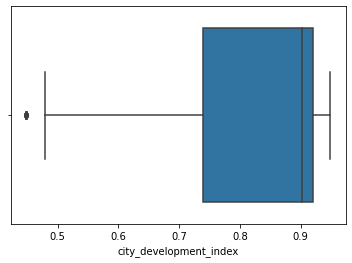

```python
sns.boxplot(x = X_hr['city_development_index'])
```

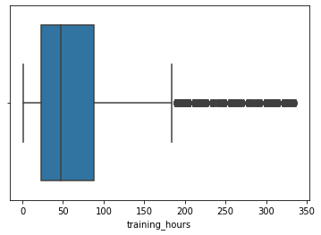

```python
sns.boxplot(x = X_hr['training_hours'])
```

Выбросы есть, согласно критерию, что выбросы выходят за границы "ящика с усами"

### Задание 5 (1 балл)

Выполните задание для датасета *hr*.

Закодируйте категориальные признаки при помощи One-hot encoding/Label encoding/Frequency encoding. Объясните свой выбор. (Обратите внимание, что некоторые категориальные признаки предполагают ранжирование в своих значениях)

```python
X_hr_fill
```

|  | enrollee_id | city | city_development_index | gender | relevent_experience | enrolled_university | education_level | major_discipline | experience | company_size | company_type | last_new_job | training_hours |
| --- | --- | --- | --- | --- | --- | --- | --- | --- | --- | --- | --- | --- | --- |
| 0 | 8949 | city_103 | 0.920 | Male | Has relevent experience | no_enrollment | Graduate | STEM | >20 | 50-99 | Pvt Ltd | 1 | 36 |
| 1 | 29725 | city_40 | 0.776 | Male | No relevent experience | no_enrollment | Graduate | STEM | 15 | 50-99 | Pvt Ltd | >4 | 47 |
| 2 | 11561 | city_21 | 0.624 | Male | No relevent experience | Full time course | Graduate | STEM | 5 | 50-99 | Pvt Ltd | never | 83 |
| 3 | 33241 | city_115 | 0.789 | Male | No relevent experience | no_enrollment | Graduate | Business Degree | <1 | 50-99 | Pvt Ltd | never | 52 |
| 4 | 666 | city_162 | 0.767 | Male | Has relevent experience | no_enrollment | Masters | STEM | >20 | 50-99 | Funded Startup | 4 | 8 |
| ... | ... | ... | ... | ... | ... | ... | ... | ... | ... | ... | ... | ... | ... |
| 19153 | 7386 | city_173 | 0.878 | Male | No relevent experience | no_enrollment | Graduate | Humanities | 14 | 50-99 | Pvt Ltd | 1 | 42 |
| 19154 | 31398 | city_103 | 0.920 | Male | Has relevent experience | no_enrollment | Graduate | STEM | 14 | 50-99 | Pvt Ltd | 4 | 52 |
| 19155 | 24576 | city_103 | 0.920 | Male | Has relevent experience | no_enrollment | Graduate | STEM | >20 | 50-99 | Pvt Ltd | 4 | 44 |
| 19156 | 5756 | city_65 | 0.802 | Male | Has relevent experience | no_enrollment | High School | STEM | <1 | 500-999 | Pvt Ltd | 2 | 97 |
| 19157 | 23834 | city_67 | 0.855 | Male | No relevent experience | no_enrollment | Primary School | STEM | 2 | 50-99 | Pvt Ltd | 1 | 127 |

19158 rows × 13 columns

```python
for col in X_hr_fill.columns:
    print(col)
```

```
enrollee_id
city
city_development_index
gender
relevent_experience
enrolled_university
education_level
major_discipline
experience
company_size
company_type
last_new_job
training_hours
```

```python
cols_for_freq_enc = [
    'city',
    'gender',
    'relevent_experience',
    'enrolled_university',
    'education_level',
    'major_discipline',
    'company_type',
]

cols_for_label_enc = [
    'experience',
    'company_size',
    'last_new_job'
]

# print(sorted(list(set(X_hr_fill['experience']))),
#       sorted(list(set(X_hr_fill['company_size']))),
#       sorted(list(set(X_hr_fill['last_new_job']))), sep='\n')
```

```python
# Словари для label-кодирования
dict_exp = {
    '1':1,
    '10':10,
    '11':11,
    '12':12,
    '13':13,
    '14':14,
    '15':15,
    '16':16,
    '17':17,
    '18':18,
    '19':19,
    '2':2,
    '20':20,
    '3':3,
    '4':4,
    '5':5,
    '6':6,
    '7':7,
    '8':8,
    '9':9,
    '<1':0,
    '>20':21
}
dict_cs = {
    '10/49':1,
    '100-500':3,
    '1000-4999':5,
    '10000+':7,
    '50-99':2,
    '500-999':4,
    '5000-9999':6,
    '<10':0
}
dict_lnj = {
    '1':1,
    '2':2,
    '3':3,
    '4':4,
    '>4':5,
    'never':0
}
```

```python
def encode(X):
    # Возвращает данные без категориальных признаков
    X_encode = X.copy()
    for col in cols_for_freq_enc:
        enc = (X.groupby(col).size())/len(X)
        X_encode[col] = X_encode[col].apply(lambda x: enc[x])
    X_encode['experience'] = X_encode['experience'].apply(lambda x: dict_exp[x])
    X_encode['company_size'] = X_encode['company_size'].apply(lambda x: dict_cs[x])
    X_encode['last_new_job'] = X_encode['last_new_job'].apply(lambda x: dict_lnj[x])
    return X_encode
```

```python
X_hr_encode = encode(X_hr_fill)
```

Будем кодировать с помощью label-encoding:

- **experience**
- **company_size**
- **last_new_job**

Будем кодировать с помощью frequency-encoding все остальные

One-hot encoding применяться не будет, так как появятся слишком много дополнительных фич.

### Задание 5 (1 балл)

Выполните задание для датасета *hr*.

#### 1. (1 балл)

Реализуйте функцию undersampling

#### 2. (1 балл)

Реализуйте функцию oversampling

```python
def undersampling(X, y):
    # Возвращает данные, сбалансированные методом undersampling
    if len(X) == len(y):
        return X.copy(), y.copy()
    elif len(X) > len(y):
        X_under = X.sample(len(y))
        y_under = y
    else:
        y_under = y.sample(len(X))
        X_under = X

    return X_under.copy(), y_under.copy()

def oversampling(X, y):
    # Возвращает данные, сбалансированные методом undersampling
    if len(X) == len(y):
        return X.copy(), y.copy()
    elif len(X) > len(y):
        y_temp = y.sample(len(X) - len(y))
        y_over = pd.concat([y,y_temp])
        X_over = X
    else:
        X_temp = X.sample(len(y) - len(X))
        X_over = pd.concat([X, X_temp])
        y_over = y
    return X_over.copy(), y_over.copy()
```

```python
X_hr_under, y_hr_under = undersampling(X_hr_encode, y_hr_fill)

X_hr_over, y_hr_over = oversampling(X_hr_encode, y_hr_fill)
```

#### 3. (1 балл)

Используйте *SMOTE* для балансировки датасета.

Помимо методов *undersampling* и *oversampling* существует подход, генерирующий элементы класса-меньшинства, похожие на уже присутствующие в выборке данных. Такой метод называется *Synthetic Minority Oversampling Technique* (SMOTE).

Метод *SMOTE* , реализованный в библиотеке `imblearn`, генерирует синтетические примеры при помощи **k-nearest neighbor** алгоритма (подробнее об этом алгоритме будет рассказано на лекции).

```python
!pip install -U imbalanced-learn
```

```python
from imblearn.over_sampling import SMOTE

smote = SMOTE()# YOUR_CODE
X_hr_SMOTE, y_hr_SMOTE = smote.fit_resample(X_hr_encode.copy(), y_hr_fill.copy())# YOUR_CODE
```

#### 4. (0.5 балла)

Как изменились распределения признаков при различных тактиках балансирования датасета?

```python
# YOUR CODE
!mkdir lets-plot-images/comp_sampling
X_hr_encode['label'] = 'Before sampling'
X_hr_under['label'] = 'Undersampling'
X_hr_over['label'] = 'Oversampling'
X_hr_SMOTE['label'] = 'SMOTE-sampling'
X_hr_result = pd.concat([X_hr_encode, X_hr_under, X_hr_over, X_hr_SMOTE]).copy()
for col in X_hr_result.columns:
    plot = ggplot(X_hr_result, aes(col)) + geom_histogram(col = 'darkblue', fill='lightblue') +\
    facet_wrap('label') + ggtitle(col + '_result_comparsion')# + ggsize(1700,850)
    ggsave(plot, "comp_sampling/" + col + '.result.comparsion.html')
```

```python
# X_hr_under['label'] = 'Undersampling'
X_hr_encode['label']
```

```
0        Before sampling
1        Before sampling
2        Before sampling
3        Before sampling
4        Before sampling
              ...
19153    Before sampling
19154    Before sampling
19155    Before sampling
19156    Before sampling
19157    Before sampling
Name: label, Length: 19158, dtype: object
```

Ввиду того, что вовремя кодирования не было удалено ни одной строчки, распределение при over- и undersampling не отличаются. Только SMOTE-sampling немного поменяло распределение

Графики:

- enrollee_id_comparsion
- city_comparsion
- city_development_index_comparsion
- gender_comparsion
- relevent_experience_comparsion
- enrolled_university_comparsion
- education_level_comparsion
- major_discipline_comparsion
- experience_comparsion
- company_size_comparsion
- company_type_comparsion
- last_new_job_comparsion
- training_hours_comparsion